# Data loading and cleaning - BRFSS

# 1 Research question

> What demographic, socioeconomic and behavioral factors predict participation in preventive cancer screening?

### 1.0.1 Source

Dataset: https://www.cdc.gov/brfss/annual_data/annual_2024.html

## 1.1 Package loading

## 1.2 Data loading

```r
brfss_complete <- read.xport('BRFSS_2024.XPT')

sprintf("BRFSS data have %d records and %d number of variables",
        nrow(brfss_complete),
        ncol(brfss_complete))
```

```
## [1] "BRFSS data have 457670 records and 301 number of variables"
```

```r
brfss_complete[1:5, 1:10] # just to get familiar with the dataset
```

```
##   X_STATE FMONTH    IDATE IMONTH IDAY IYEAR DISPCODE      SEQNO     X_PSU
## 1       1      2 02282024     02   28  2024     1100 2024000001 2.024e+09
## 2       1      2 02212024     02   21  2024     1100 2024000002 2.024e+09
## 3       1      2 02212024     02   21  2024     1100 2024000003 2.024e+09
## 4       1      2 02282024     02   28  2024     1100 2024000004 2.024e+09
## 5       1      2 02212024     02   21  2024     1100 2024000005 2.024e+09
##   CTELENM1
## 1        1
## 2        1
## 3        1
## 4        1
## 5        1
```

### 1.2.1 Interesting variables

#### 1.2.1.1 Demographic features

- `_STATE`: US State
- `_AGE_G`: Six-level imputed age category
- `_SEX`: Sex variable
- `_RACE`: Race/ethnicity categories
- `MARITAL`: marital status
- `VETERAN3`: Have you ever served on active duty in the United States Armed Forces, either in the regular military or in a National Guard or military reserve unit?

#### 1.2.1.2 Cancer screening participation

Absolute answers:

- `CERVSCRN`: Have you ever had a cervical cancer screening test?
  - `CRVCLPAP`: At your most recent cervical cancer screening, did you have a Pap test?
  - `CRVCLHPV`: At your most recent cervical cancer screening, did you have an H.P.V. test?
- `HADMAM`: Have you ever had a mammogram?
- `HADSIGM4`: Colonoscopy and sigmoidoscopy are exams to check for colon cancer. Have you ever had either of these exams?
- `SMALSTOL`: One stool test uses a special kit to obtain a small amount of stool at home and returns the kit to the doctor or the lab. Have you ever had this test?
- `LCSCTSC1`: Have you ever had a CT or CAT scan of your chest area?
- `PSATEST1`: Have you ever had a P.S.A. test?

Including recency:

- `_RFPAP37`: [combined] Female respondents with and intact cervix, aged 21-65, who have had a pap test in the past three years
- `_PAPHPV1`: [combined] Female respondents with an intact cervix, aged 21-65 that have had a pap test in last 3 years or aged 30-65 that have had an HPV test in last 5 years
- `_HPV5YR1`: [combined] Female respondents with and intact cervix, aged 30-65, who have had an HPV test in the past five years
- `_RFMAM23`: Women respondents aged 40+ who have had a mammogram in the past two years
- `_MAM402Y`: Women respondents aged 40-74 who have had a mammogram in the past two years

#### 1.2.1.3 Socioeconomic factors

- `_INCOMG1`: Income categories (better grouping)
- `_EDUCAG`: Level of education completed (better grouping) [alternative `EDUCA`]
- `EMPLOY1`: Employment status
- `RENTHOM1`: Do you own or rent your home?
- [maybe too complicated to include them] `FOODSTMP` / `SDHFOOD1` / `SDHBILLS` / `SDHUTILS` / `SDHTRNSP`: food stamps, food insecurity, unable to pay bills, utility cutoff, transportation barriers

#### 1.2.1.4 Insurance coverage

- `_HLTHPL2`: Adults who had some form of health insurance
  - `_HCVU654`: Respondents aged 18-64 who have any form of health insurance
- `PERSDOC3`: Do you have one person or a group of doctors that you think of as your personal health care provider?
- `MEDCOST1`: Was there a time in the past 12 months when you needed to see a doctor but could not because you could not afford it?

#### 1.2.1.5 Behavioural

- `_RFSMOK3`: Adults who are current smokers
- `EXERANY2`: During the past month, other than your regular job, did you participate in any physical activities or exercises such as running, calisthenics, golf, gardening, or walking for exercise?
- `_BMI5`: BMI (continuous)
- `_RFDRHV9`: Heavy drinkers (adult men having more than 14 drinks per week and adult women having more than 7 drinks per week)

#### 1.2.1.6 Other

- `HADHYST2`: Have you had a hysterectomy? (to exclude from cervical screening)

#### 1.2.1.7 Weights and data

- `_PSU`: Primary Sampling Unit (Equal to Annual Sequence Number)
- `_LLCPWT`: Final weight assigned to each respondent: Land-line and cell-phone data (Raking derived weight)
- `_STSTR`: Sample Design Stratification Variable

```r
# to be refined
sel_variables <- c(
  "X_PSU", "X_STSTR", "X_LLCPWT", # Weights
  "X_STATE", "X_AGE_G", "X_SEX", "X_RACE", "MARITAL", "VETERAN3", # Demographics
  "CERVSCRN", "CRVCLPAP", "CRVCLHPV", "HADMAM", "HADSIGM4", # Cancer screening (absolute)
  "SMALSTOL", "LCSCTSC1", "PSATEST1",
  "X_RFPAP37", "X_PAPHPV1", "X_HPV5YR1", "X_RFMAM23", "X_MAM402Y", # Cancer screening (recency / combined)
  "X_INCOMG1", "X_EDUCAG", "EMPLOY1", "RENTHOM1", # Socioeconomic
  "X_HLTHPL2", "X_HCVU654", "PERSDOC3", "MEDCOST1", # Insurance
  "X_RFSMOK3", "EXERANY2", "X_BMI5", "X_RFDRHV9" # Behavioral
)

brfss24 <- brfss_complete %>%
  select(any_of(sel_variables))
```

### 1.2.2 Data cleaning

Cleaning and re-levelling the data:

```r
brfss24 <- brfss24 %>%
  mutate(across(-X_RACE, ~ na_if(., 7))) %>% # transforming 7, 9, 77 and 99 values into NAs
  mutate(across(everything(), ~ na_if(., 9))) %>%
  mutate(across(everything(), ~ na_if(., 77))) %>%
  mutate(across(everything(), ~ na_if(., 99))) %>%
  mutate(
    X_STATE = factor(
      as.character(X_STATE),
      levels = names(state_labels), # hidden chunk in knitted file
      labels = state_labels
    ),
    X_SEX = factor(
      X_SEX,
      levels = c(1, 2),
      labels = c("Male", "Female")
    ),
    MARITAL = factor(
      MARITAL,
      levels = 1:6,
      labels = c(
        "Married",
        "Divorced",
        "Widowed",
        "Separated",
        "Never married",
        "Unmarried couple"
      )
    ),
    VETERAN3 = factor(
      VETERAN3,
      levels = c(1, 2),
      labels = c("Yes", "No")
    ),
    X_AGE_G = factor(
      X_AGE_G,
      levels = 1:6,
      labels = c(
        "Age 18 to 24",
        "Age 25 to 34",
        "Age 35 to 44",
        "Age 45 to 54",
        "Age 55 to 64",
        "Age 65 or older"
      ),
      ordered = TRUE
    ),
    X_INCOMG1 = factor(
      X_INCOMG1,
      levels = 1:7,
      labels = c(
        "<15k",
        "15–25k",
        "25–35k",
        "35–50k",
        "50–100k",
        "100–200k",
        "200k+"
      )
    ),

    X_EDUCAG = factor(X_EDUCAG, ordered = TRUE),
    EMPLOY1  = factor(EMPLOY1),
    RENTHOM1 = factor(RENTHOM1),
    X_HLTHPL2 = factor(
      X_HLTHPL2,
      levels = c(1, 2),
      labels = c("Insured", "Not insured")
    ),
    PERSDOC3 = factor(
      PERSDOC3,
      levels = c(1, 2, 3),
      labels = c(
        "Yes, one",
        "Yes, more than one",
        "No"
      )
    ),
    MEDCOST1 = factor(
      MEDCOST1,
      levels = c(1, 2),
      labels = c("Yes", "No")
    ),
    X_HCVU654 = factor(
      X_HCVU654,
      levels = c(1, 2),
      labels = c(
        "Yes",
        "No"
      )
    ),
    X_RFSMOK3 = factor(X_RFSMOK3),
    EXERANY2 = factor(
      EXERANY2,
      levels = c(1, 2),
      labels = c("Yes", "No")
    ),
    X_RFDRHV9 = factor(X_RFDRHV9),
    X_BMI5 = as.numeric(X_BMI5),
    X_RACE = factor(
      X_RACE,
      levels = 1:8,
      labels = c(
        "White only, non-Hispanic",
        "Black only, non-Hispanic",
        "American Indian or Alaskan Native only, non-Hispanic",
        "Asian only, non-Hispanic",
        "Native Hawaiian or other Pacific Islander only, non-Hispanic",
        "Other race only, non-Hispanic",
        "Multiracial, non-Hispanic",
        "Hispanic"
      )
    ),
    CERVSCRN = factor(
      CERVSCRN,
      levels = c(1, 2),
      labels = c("Yes", "No")
    ),
    CRVCLPAP = factor(
      CRVCLPAP,
      levels = c(1, 2),
      labels = c("Yes", "No")
    ),
    CRVCLHPV = factor(
      CRVCLHPV,
      levels = c(1, 2),
      labels = c("Yes", "No")
    ),
    X_RFPAP37 = factor(
      X_RFPAP37,
      levels = c(1, 2),
      labels = c(
        "Had PAP test in last 3 years",
        "Had PAP test more than 3 years ago or have not had one"
      )
    ),
    X_PAPHPV1 = factor(
      X_PAPHPV1,
      levels = c(1, 2),
      labels = c(
        "Had PAP test in last 3 years or HPV test in last 5 years",
        "Have not had PAP test in last 3 years and HPV test in last 5 years"
      )
    ),
    X_HPV5YR1 = factor(
      X_HPV5YR1,
      levels = c(1, 2),
      labels = c(
        "Had HPV test in last 5 years",
        "Had HPV test more than 5 years ago or have not had one"
      )
    ),
    HADMAM = factor(
      HADMAM,
      levels = c(1, 2),
      labels = c("Yes", "No")
    ),
    X_RFMAM23 = factor(
      X_RFMAM23,
      levels = c(1, 2),
      labels = c("Yes", "No")
    ),
    X_MAM402Y = factor(
      X_MAM402Y,
      levels = c(1, 2),
      labels = c(
        "Yes",
        "No"
      )
    ),
    HADSIGM4 = factor(
      HADSIGM4,
      levels = c(1, 2),
      labels = c("Yes", "No")
    ),
    SMALSTOL = factor(
      SMALSTOL,
      levels = c(1, 2),
      labels = c("Yes", "No")
    ),
    LCSCTSC1 = factor(
      LCSCTSC1,
      levels = c(1, 2),
      labels = c("Yes", "No")
    ),
    PSATEST1 = factor(
      PSATEST1,
      levels = c(1, 2),
      labels = c("Yes", "No")
    )

  )
```

If we had to convert it into a survey design object:

```r
brfss.design <- brfss24 %>%
  select(any_of(sel_variables)) %>%
  as_survey_design(
    ids = X_PSU,
    weights = X_LLCPWT,
    strata = X_STSTR,
    nest = TRUE
  )
```

### 1.2.3 Taking a glimpse of what the data looks like

```r
glimpse(brfss24)
```

```
## Rows: 457,670
## Columns: 34
## $ X_PSU     <dbl> 2.024e+09, 2.024e+09, 2.024e+09, 2.024e+09, 2.024e+09, 2.024…
## $ X_STSTR   <dbl> 11011, 11011, 11011, 11011, 11011, 11011, 11011, 11011, 1101…
## $ X_LLCPWT  <dbl> 261.5255, 307.1697, 2939.8628, 153.5848, 1229.6230, 451.2199…
## $ X_STATE   <fct> Alabama, Alabama, Alabama, Alabama, Alabama, Alabama, Alabam…
## $ X_AGE_G   <ord> Age 65 or older, Age 65 or older, Age 55 to 64, Age 65 or ol…
## $ X_SEX     <fct> Female, Male, Male, Male, Male, Male, Female, Female, Female…
## $ X_RACE    <fct> "White only, non-Hispanic", "White only, non-Hispanic", "Whi…
## $ MARITAL   <fct> Widowed, Married, Unmarried couple, Married, Never married, …
## $ VETERAN3  <fct> No, Yes, Yes, No, No, No, No, No, No, Yes, No, No, Yes, Yes,…
## $ CERVSCRN  <fct> Yes, NA, NA, NA, NA, NA, Yes, Yes, Yes, NA, Yes, NA, NA, NA,…
## $ CRVCLPAP  <fct> Yes, NA, NA, NA, NA, NA, Yes, No, Yes, NA, Yes, NA, NA, NA, …
## $ CRVCLHPV  <fct> No, NA, NA, NA, NA, NA, NA, No, No, NA, No, NA, NA, NA, No, …
## $ HADMAM    <fct> Yes, NA, NA, NA, NA, NA, Yes, Yes, Yes, NA, Yes, NA, NA, NA,…
```

[output cut: 21 more lines]

Summary:

```r
brfss24 %>%
  select(-X_PSU, -X_STSTR, -X_LLCPWT) %>%
  summary()
```

```
##        X_STATE                  X_AGE_G          X_SEX
##  New York  : 43913   Age 18 to 24   : 29694   Male  :217507
##  Washington: 25800   Age 25 to 34   : 49994   Female:240163
##  Minnesota : 15199   Age 35 to 44   : 60418
##  Maryland  : 14462   Age 45 to 54   : 64458
##  Wisconsin : 13096   Age 55 to 64   : 80280
##  (Other)   :337987   Age 65 or older:172826
##  NA's      :  7213
##                        X_RACE                   MARITAL       VETERAN3
##  White only, non-Hispanic :329346   Married         :229393   Yes : 52504
##  Hispanic                 : 48646   Divorced        : 58827   No  :402590
##  Black only, non-Hispanic : 35172   Widowed         : 49161   NA's:  2576
##  Asian only, non-Hispanic : 12646   Separated       :  9462
##  Multiracial, non-Hispanic: 10486   Never married   : 84851
##  (Other)                  : 12271   Unmarried couple: 21754
##  NA's                     :  9103   NA's            :  4222
##  CERVSCRN      CRVCLPAP      CRVCLHPV       HADMAM       HADSIGM4
##  Yes :178450   Yes :160390   Yes : 50511   Yes :177211   Yes :227444
##  No  : 40618   No  : 11327   No  : 81323   No  : 49608   No  : 71368
##  NA's:238602   NA's:285953   NA's:325836   NA's:230851   NA's:158858
##
##
##
##
##  SMALSTOL      LCSCTSC1      PSATEST1
##  Yes : 57040   Yes :182511   Yes :  9014
##  No  : 14343   No  :222258   No  :  7570
##  NA's:386287   NA's: 52901   NA's:441086
##
##
##
##
##                                                   X_RFPAP37
##  Had PAP test in last 3 years                          : 68504
##  Had PAP test more than 3 years ago or have not had one: 34710
##  NA's                                                  :354456
##
##
##
##
```

[output cut: 25 more lines]

```
##  Insured    :413720   Yes :242615   Yes, one          :242393   Yes : 43363
##  Not insured: 25406   No  : 24019   Yes, more than one:154558   No  :412634
##  NA's       : 18544   NA's:191036   No                : 56106   NA's:  1673
##                                     NA's              :  4613
##
##
##
##  X_RFSMOK3     EXERANY2          X_BMI5      X_RFDRHV9
##  1   :378554   Yes :350061   Min.   :1200    1   :386812
##  2   : 47094   No  :106294   1st Qu.:2414    2   : 24160
##  NA's: 32022   NA's:  1315   Median :2744    NA's: 46698
##                              Mean   :2856
##                              3rd Qu.:3175
##                              Max.   :9984
##                              NA's   :43037
```

## 1.3 Exploratory analysis

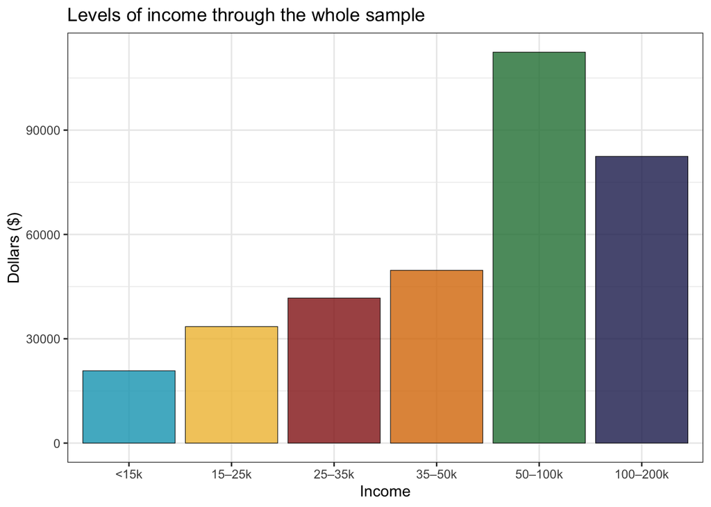

```r
ggplot(brfss24 %>% drop_na(X_INCOMG1)) +
  geom_bar(
    aes(X_INCOMG1, fill = X_INCOMG1),
    col = "black",
    linewidth = 0.2,
    alpha = .8
  ) +
  labs(x = "Income", y = "Dollars ($)", title = "Levels of income through the whole sample") +
  scale_fill_palette_d(met_palettes$Lakota) +
  theme_bw() +
  theme(legend.position = "none")
```

```r
scree_part <- brfss24 %>%
  select(CERVSCRN,
         CRVCLPAP,
         CRVCLHPV,
         HADMAM,
         HADSIGM4,
         SMALSTOL,
         LCSCTSC1,
         PSATEST1) %>%
  pivot_longer(cols = everything(),
               names_to = "screening",
               values_to = "response") %>%
  filter(!is.na(response)) %>%
  group_by(screening) %>%
  summarise(count = n(), perc_yes = round(mean(response == "Yes"), 4) *
              100)

kable(scree_part, format = "html", caption = "Screening Participation") %>%
  kable_styling(
    bootstrap_options = c("striped", "hover", "condensed"),
    full_width = FALSE
  ) %>%
  column_spec(1, bold = TRUE) %>%
  add_header_above(c(" " = 1, "Summary Statistics" = 2))
```

Screening Participation

| screening | Summary Statistics count | Summary Statistics perc_yes |
| --- | --- | --- |
| CERVSCRN | 219068 | 81.46 |
| CRVCLHPV | 131834 | 38.31 |
| CRVCLPAP | 171717 | 93.40 |
| HADMAM | 226819 | 78.13 |
| HADSIGM4 | 298812 | 76.12 |
| LCSCTSC1 | 404769 | 45.09 |
| PSATEST1 | 16584 | 54.35 |
| SMALSTOL | 71383 | 79.91 |

## 1.4 References

- https://ikwak2.github.io/tutorials/BRFSS/BRFSS.html